# R4DS_2E_layers

```r
# In terms of the plots, visually there is no difference between either of them. However, adding the argument `position = "identity"` might be good code practice when making plots which involve overlapping data to inform the user running the code.
```

3. What parameters to geom_jitter() control the amount of jittering?

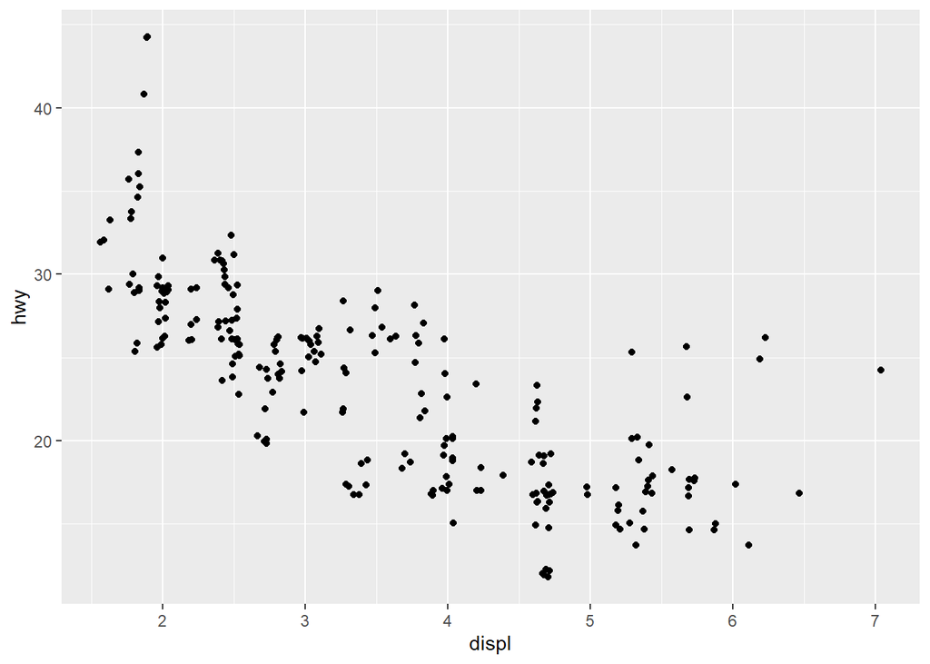

```r
# width and height control the amount of jitter. From the documentation:

# width, height:
# Amount of vertical and horizontal jitter. The jitter is added in both positive and negative directions, so the total spread is twice the value specified here.
# If omitted, defaults to 40% of the resolution of the data: this means the jitter values will occupy 80% of the implied bins. Categorical data is aligned on the integers, so a width or height of 0.5 will spread the data so it's not possible to see the distinction between the categories.

# Lets see these arguments in action with some examples:

ggplot(mpg, aes(x = displ, y = hwy)) +
  geom_jitter()
```

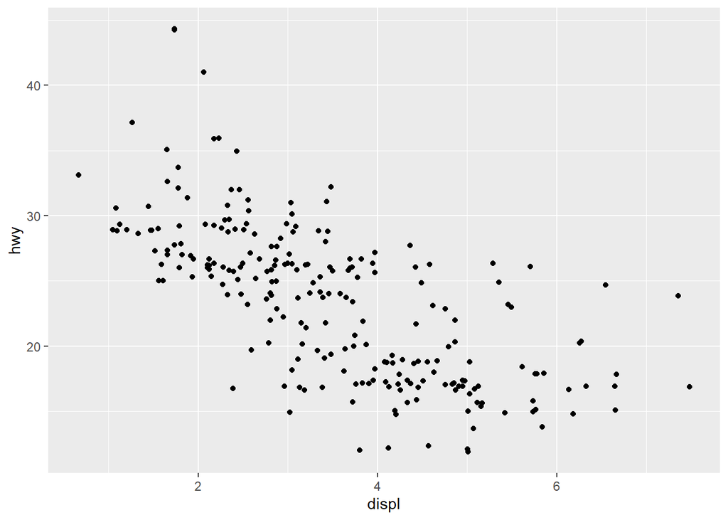

```r
ggplot(mpg, aes(x = displ, y = hwy)) +
  geom_jitter(width = 1)
```

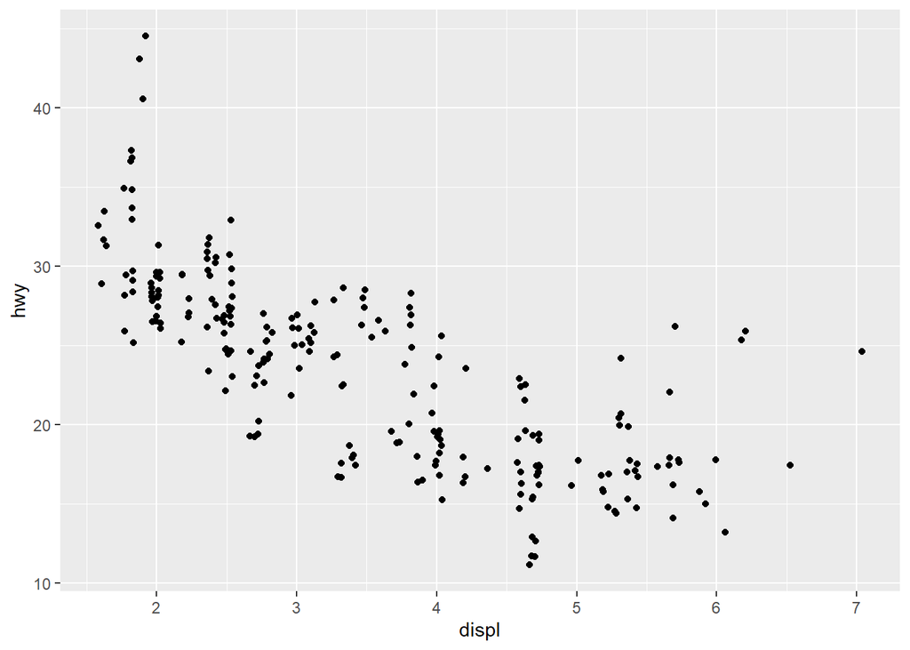

```r
ggplot(mpg, aes(x = displ, y = hwy)) +
  geom_jitter(height = 1)
```

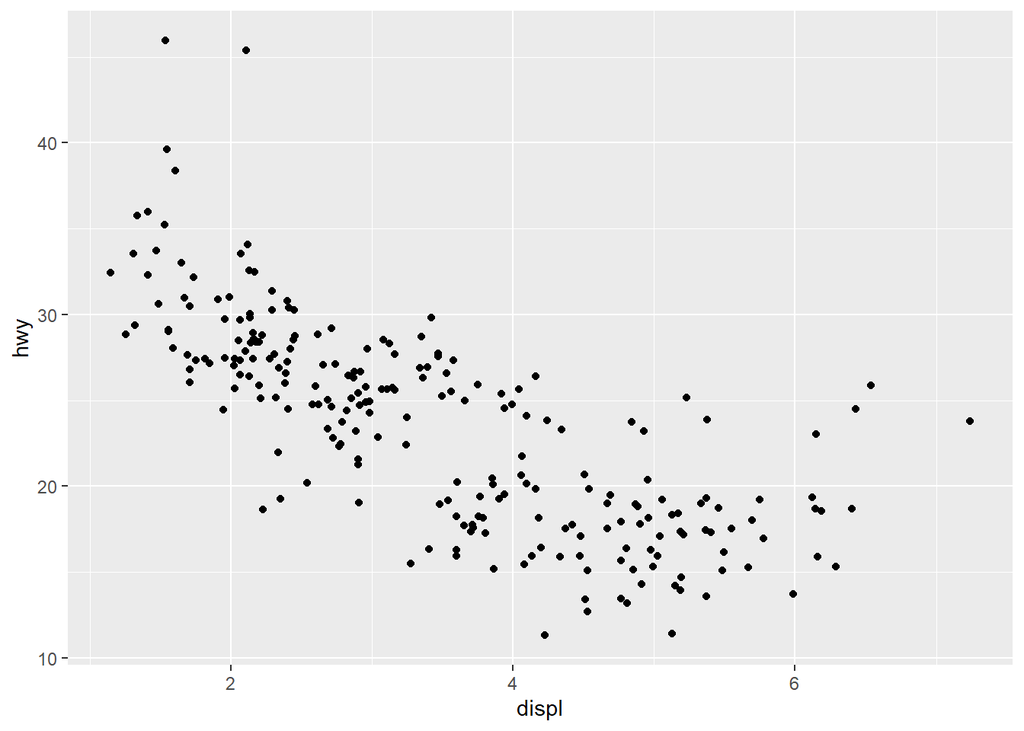

```r
ggplot(mpg, aes(x = displ, y = hwy)) +
  geom_jitter(width = 0.5, height = 2)
```

4. Compare and contrast geom_jitter() with geom_count().

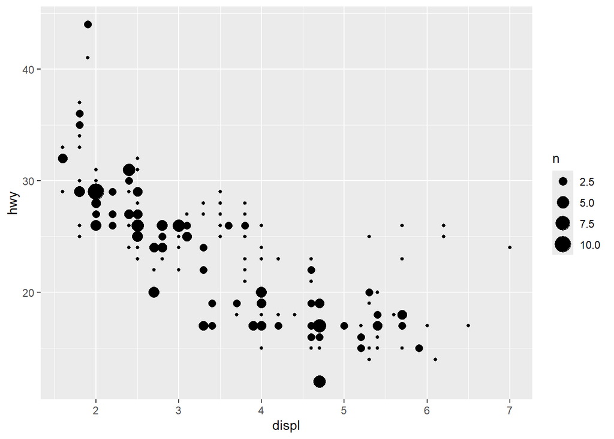

```r
ggplot(mpg, aes(x = displ, y = hwy)) +
  geom_count()
```

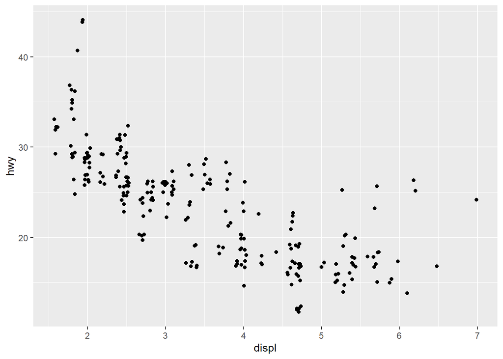

```r
ggplot(mpg, aes(x = displ, y = hwy)) +
  geom_jitter()
```

```r
# `geom_count()` creates a legend displaying a rough estimate of how much overlapping we have on particular points. This can also be useful to visually identify how much overlapping we have at each point without sacrificing the accuracy of where the points should be displayed unlike with `geom_jitter()`. However with plots where data points are very close together, I imagine geom_count is not as good as there could be a lot of overlap between points, again obscuring overlapping of the data. Also since geom_count creates "buckets" of data (In the above example we have n = 2.5, 5, etc.), if there are many different "buckets" it can get a bit overwhelming visually.
```

5. What’s the default position adjustment for geom_boxplot()? Create a visualization of the mpg dataset that demonstrates it.

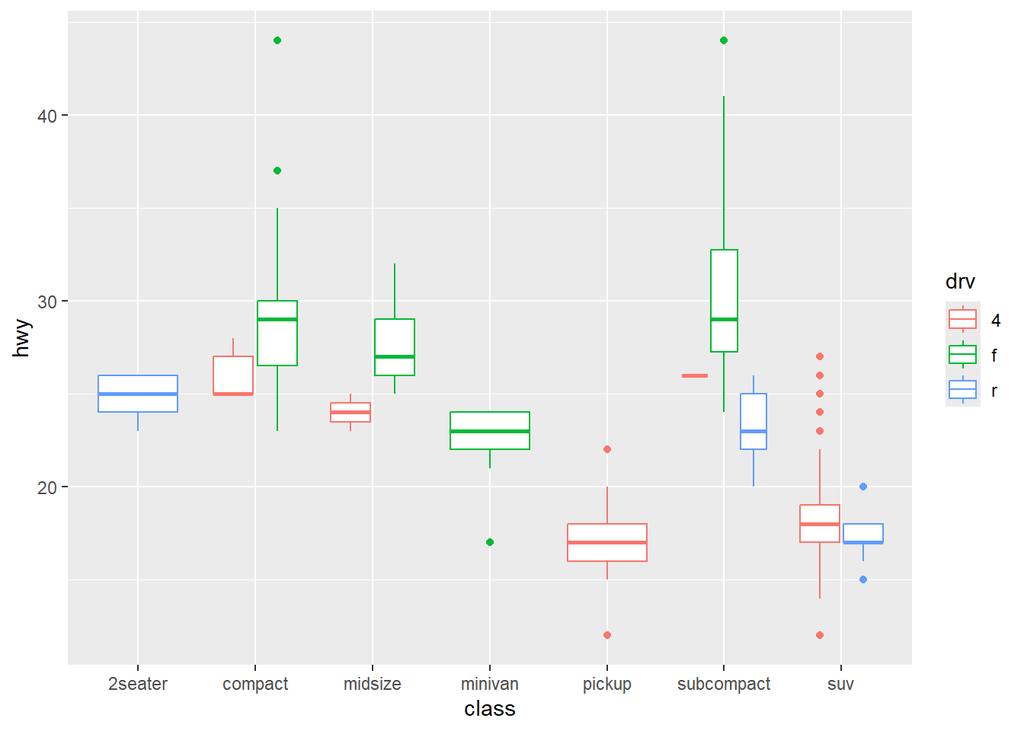

```r
# Default position is "dodge2"
ggplot(mpg, aes(class, hwy)) +
  geom_boxplot(aes(colour = drv))
```

```r
# So each boxplot relating class, hwy and their respective drv is automatically shown close to each other, as is the expected behaviour of position adjustment "dodge"
```

## Layers - Coordinate systems

1. Turn a stacked bar chart into a pie chart using coord_polar().

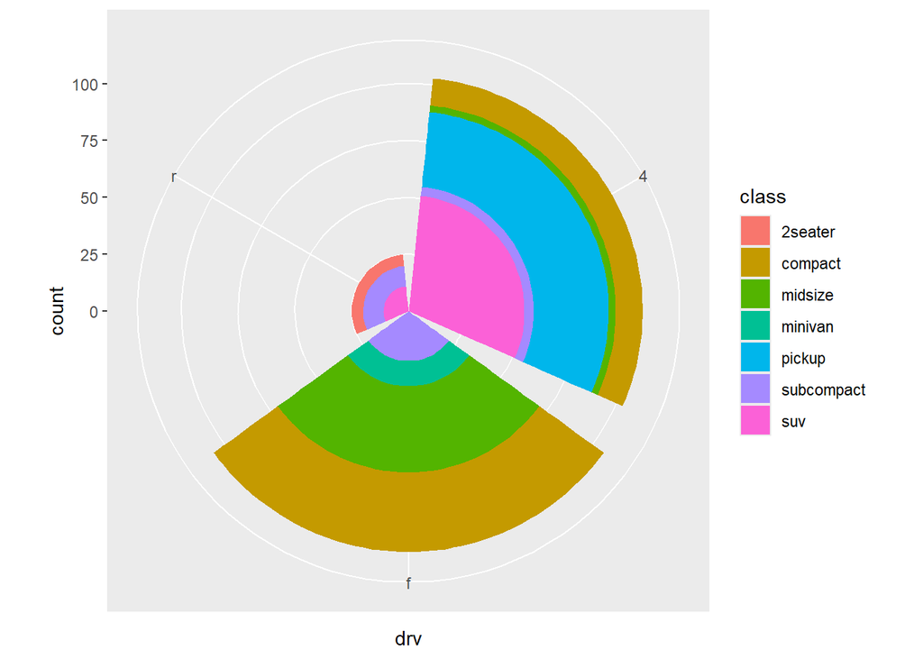

```r
ggplot(mpg, aes(x = drv, fill = class)) +
  geom_bar() +
  coord_polar()
```

2. What’s the difference between coord_quickmap() and coord_map()?

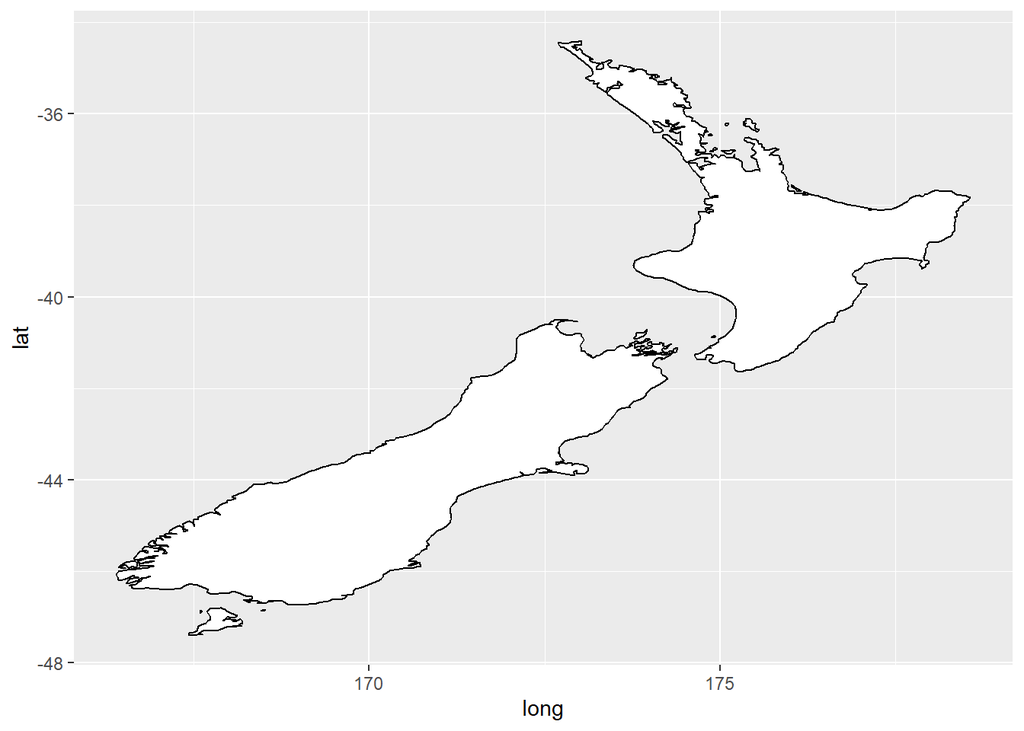

```r
nz <- map_data("nz")

ggplot(nz, aes(x = long, y = lat, group = group)) +
  geom_polygon(fill = "white", color = "black")
```

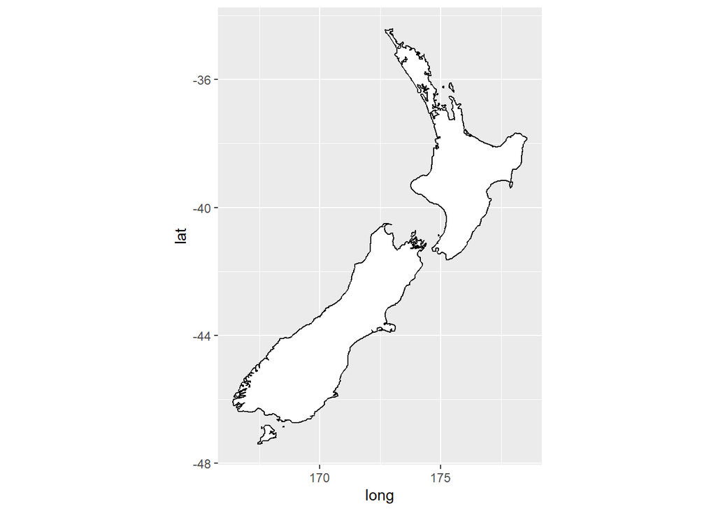

```r
ggplot(nz, aes(x = long, y = lat, group = group)) +
  geom_polygon(fill = "white", color = "black") +
  coord_quickmap()
```

```r
# Without looking at any documentation, at first glance `coord_quickmap()` appears to have a much more accurate aspect ratio which represents New Zealand much better.
# coord_map() projects a portion of the earth, which is approximately spherical, onto a flat 2D plane using any projection defined by the mapproj package. Map projections do not, in general, preserve straight lines, so this requires considerable computation. coord_quickmap() is a quick approximation that does preserve straight lines. It works best for smaller areas closer to the equator.
```

3. What does the following plot tell you about the relationship between city and highway mpg? Why is coord_fixed() important? What does geom_abline() do?

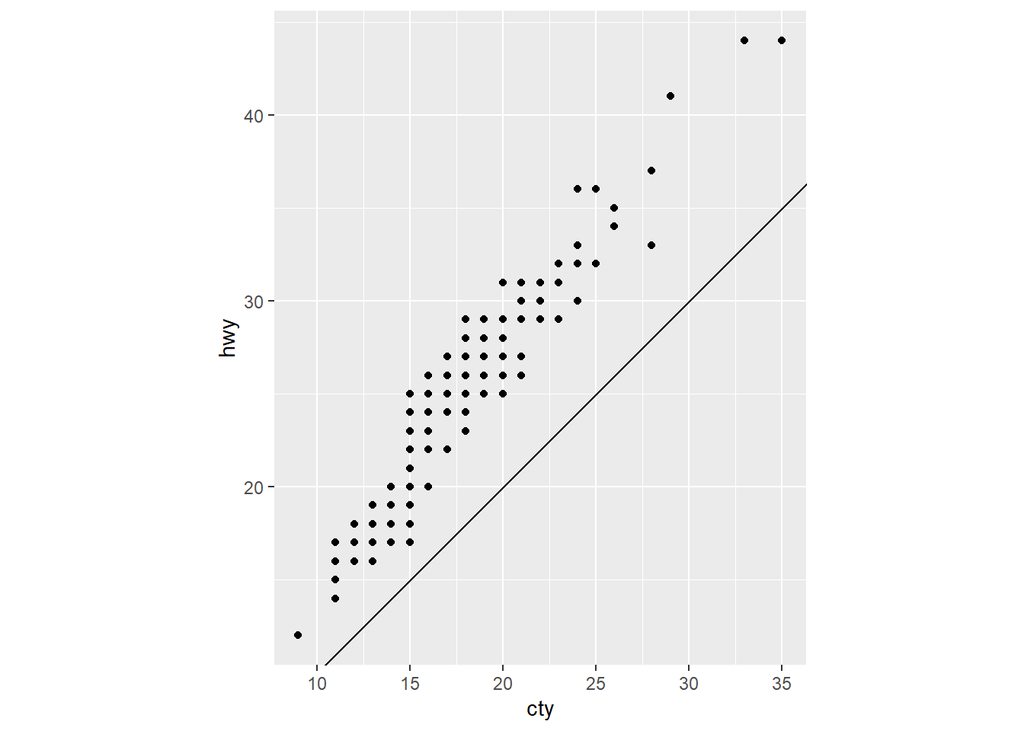

```r
ggplot(data = mpg, mapping = aes(x = cty, y = hwy)) +
  geom_point() +
  geom_abline() +
  coord_fixed()
```

```r
# As city miles per gallon goes up, highway miles per gallon also increases
# `coord_fixed()` is important as it forces a better specified ratio between the x-axis and y-axis. The ratio is 1:1 (each unit increase in the x-axis is the same distance as each unit increase in the y-axis). This gives us a much better representation of the relationship between cty and hwy
# `geom_abline()` adds a diagonal line through the plot which goes through the origin point. This helps us see that as each unit increase in cty there is a higher proportionate increase in hwy (as all data points are above the diagonal)
```